# Tema 11 - kNN

Análisis de Datos Multivariantes aplicado al Marketing - Curso 2023/24  
Universidad de Alicante

Pedro Albarrán

Dpto. de Fundamentos del Análisis Económico. Universidad de Alicante

## k-NN (‘k-nearest neighbors’)

- Métodos paramétricos = supuesto funcional para la **esperanza condicional**
  - variable numérica $\small E[y|\mathbf{X}=x_0]=f(x_0)=\beta_0+\beta_1 x_0$
  - variable categórica: $\small \Pr(y=j|\mathbf{X}=x_0) =f_j(x_0)=\Lambda(\beta_{0j}+\beta_{1j} x_0)$
- k-NN estima la esperanza condicional de forma no parámetrica
- Idea: el valor esperado de $\small y$ para una observación debe ser “similar” al de otras observaciones “cercanas” (por su valor en $\small \mathbf{X}$)
  - mismo valor de $\small x_0$, mismo valor esperado de $\small y$
  - $\small f(\mathbf{X})$ no se supone conocida y fija

## Algoritmo k-NN

- Dada una muestra de entrenamiento y una nueva observación $\small \mathbf{x^*}$
1. Identificar $\small k>0$ observaciones cercanas según una norma, ej., $\small ||x^*-x_i||_2$
2. Se asigna a $\small y^*$ la media o la clase mayoritaria de las observaciones cercanas

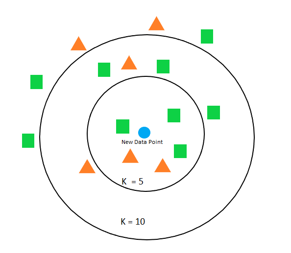

- El valor “óptimo” de $k$ se elige mediante validación cruzada.
  - $\small k$ bajo (= algoritmo demasiado flexible): alta varianza y sesgo bajo
  - Al aumentar $\small k$ (menos flexible), menor varianza, pero mayor sesgo

## Algoritmo k-NN: comentarios

- Su utilidad depende de la geometría de los datos
  - conviene centrar y reescalar los datos
  - probar varias medidas de distancia: valor absoluto $\small |x^*-x_i|$ , norma
- La distancia solo se puede calcular para variables continuas: convertir factores en dummies (una para cada categoría)
- NO es necesario incluir transformaciones no lineales de los regresores (ej., polinomios, interacción, etc.) en la receta
- LASSO (modelo lineal) puede no ser informativo sobre la elección de variables para este algoritmo
- Implementación en R con bibliotecas `class` y `kknn`